# happinesrank_2017

## K-means kümeleme algoritması

K-means kümeleme yöntemi N adet veri nesnesinden oluşan bir veri kümesini giriş parametresi olarak verilen K adet kümeye bölümlemektir. Amaç, gerçekleştirilen bölümleme işlemi sonunda elde edilen kümelerin, küme içi benzerliklerinin maksimum ve kümeler arası benzerliklerinin ise minimum olmasını sağlamaktır.

K-means en sık kullanılan kümeleme algoritmalarındandır. Uygulanması kolaydır. Büyük ölçekli verileri hızlı ve etkin şekilde kümeleyebilir. “K” algoritmaya başlamadan önce ihtiyaç duyulan sabit küme sayısını ifade etmektedir. Tekrarlı bölümleyici yapısı ile K-means algoritması, her verinin ait olduğu kümeye olan uzaklıkları toplamını küçültmektedir. K-means algoritması karesel hatayı en küçük yapacak olan K adet kümeyi tespit etmeye çalışmaktadır.

K-means algoritmasının çalışma mekanizmasına göre öncelikle her kümenin merkez noktasını veya ortalamasını temsil etmek üzere K adet nesne rastgele seçilir. Kalan diğer nesneler, kümelerin ortalama değerlerine olan uzaklıkları dikkate alınarak en benzer oldukları kümelere dahil edilir. Daha sonra, her bir kümenin ortalama değeri hesaplanarak yeni küme merkezleri belirlenir ve tekrar nesnelerin merkeze uzaklıkları incelenir. Herhangi bir değişim olmayana kadar algoritma tekrarlamaya devam eder.

Algoritma temel olarak 4 aşamadan oluşur: 1.Küme merkezlerinin belirlenmesi 2.Merkez dışındaki verilerin mesafelerine göre kümelendirilmesi 3.Yapılan kümelendirmeye göre yeni merkezlerin belirlenmesi (veya eski merkezlerin yeni merkeze kaydırılması) 4.Kararlı hale (stable state) gelinene kadar 2. ve 3. adımların tekrarlanması

- https://makineogrenimi.wordpress.com/2017/06/23/gozetimsiz-ogrenme-k-merkezli-obekleme/
- Zaki, Mohammed J. ve Meira Wagner Jr., Data Mining And Analysis, New York: Cambridge University Press, 2014.

Elimizdeki verilerle ülkelerin mutluluk seviyelerini tahmin etmek onları gruplandırmak istiyoruz.

İlk olarak kütüphanelerimizi ekleyelim.

- numpy (Numeric-Python):Python ile bilimsel bazlı hesaplama yapabilme yeteneği olan bir kütüphanedir. NumPy sayesinde python dili ile diziler ve matrislerde işlemler kolayca yapılabilmektedir.Ayrıca kütüphanede özellik olarak N-Boyutlu dizi nesenelerinde işlem yapabilme, kütüphanenin kendisine özgü olarak özelleşmiş fonksiyonları barındırma (Fourier dönüşümleri, lineer cebir işlemleri, düzgün biçimli rastgele sayı dağılımları, düzgün biçimli olmayan sayı dağılımları vb.), C/C++ ve Fortran kodları ile tümleşik çalışabilme gibi yetenekler bulunmaktadır.
- pandas (Python Data Analysis):Python için geliştirilen yüksek performanslı, kolay kullanımlı farklı veri yapılarını (.csv, .tsv, .xlsx vs..) kullanabilmeye ve analiz edebilmeye yarayan bir kütüphanedir.
- matplotlib (Mathematical Plotting Library):Temel olarak 2-boyutlu çizimler için geliştirilmiş bir kütüphanedir. Bu kütüphane ile temel çizimlerin haricinde histogramlar, güç-yoğunlukları, sütun grafikleri, dağılım modellemeleri vb. Işlemler çok kolay şekilde gerçekleştirilebilmektedir.
- Sci-Kit Learn: NumPy, SciPy lib ve matplotlib üzerine geliştirilmiş olan veri madenciliği ve veri analizi için uygun notasyon ve algoritmaları barındıran bir kütüphanedir. İçerisinde sınıflandırma(Classification), regresyon(Regression), kümeleme(Clustering), boyutsal indirgeme(Dimensionality Reduction), model seçimi(Model Selection), ön işleme(Preprocessing) vb. Işlemler için uygun notasyon ve algoritmaları barındıran bir kütüphanedir.
- https://docs.python.org/3/library/
- http://www.kodblog.net/2018/02/24/python-kutuphaneleri/

```python
import numpy as np
import matplotlib.pyplot as plt
import pandas as pd
from sklearn.cluster import KMeans
```

Veri setini yükleyelim ve .head() yardımıyla başlıkları görüntüleyelim.

```python
dataset=pd.read_csv(r"C:\Python37\2017.csv")
dataset.head()
```

|  | Country | Happiness.Rank | Happiness.Score | Whisker.high | Whisker.low | Economy..GDP.per.Capita. | Family | Health..Life.Expectancy. | Freedom | Generosity | Trust..Government.Corruption. | Dystopia.Residual |
| --- | --- | --- | --- | --- | --- | --- | --- | --- | --- | --- | --- | --- |
| 0 | Norway | 1 | 7.537 | 7.594445 | 7.479556 | 1.616463 | 1.533524 | 0.796667 | 0.635423 | 0.362012 | 0.315964 | 2.277027 |
| 1 | Denmark | 2 | 7.522 | 7.581728 | 7.462272 | 1.482383 | 1.551122 | 0.792566 | 0.626007 | 0.355280 | 0.400770 | 2.313707 |
| 2 | Iceland | 3 | 7.504 | 7.622030 | 7.385970 | 1.480633 | 1.610574 | 0.833552 | 0.627163 | 0.475540 | 0.153527 | 2.322715 |
| 3 | Switzerland | 4 | 7.494 | 7.561772 | 7.426227 | 1.564980 | 1.516912 | 0.858131 | 0.620071 | 0.290549 | 0.367007 | 2.276716 |
| 4 | Finland | 5 | 7.469 | 7.527542 | 7.410458 | 1.443572 | 1.540247 | 0.809158 | 0.617951 | 0.245483 | 0.382612 | 2.430182 |

Veri setimizde yer almasını istemediğimiz alanları (Country,Happiness.Rank, Happiness.Score, Whisker.high, Whisker.low, Dystopia.Residual) çıkaralım.

Bunun için .iloc kullanarak sadece istediğimiz kolonlara yer verecek şekilde veri setimizi güncelleyelim.

dataset1 ve dataset2 olmak üzere iki farklı değişken tanımlayalım. dataset1'de sadece sayısal değerlerimiz olsun ve analizimizi etkileyecek sütunları çıkaralım. Yani bunun için yukarıda istemediğimiz alanlar diye belirlediğimiz alanları çıkaralım.

dataset2'de ise çalışmamızın belli bir aşamasında ülke isimlerine ihtiyacımız olacağından dataset1'den farklı olarak Country sütununa yer verelim, Happiness.Rank, Happiness.Score, Whisker.high, Whisker.low Dystopia.Residual sütunlarına yer vermeyelim.

```python
columns1=[*range(5,11)]
columns2=[0,*range(5,11)]
dataset1=dataset.iloc[:,columns1].values
dataset2=dataset.iloc[:,columns2]
dataset3=dataset.iloc[:,columns1]
```

Veri setimizin içeriğini, detaylarını göstermek için describe ile kolon bazlı detaylandıralım.

```python
dataset.describe()
```

|  | Happiness.Rank | Happiness.Score | Whisker.high | Whisker.low | Economy..GDP.per.Capita. | Family | Health..Life.Expectancy. | Freedom | Generosity | Trust..Government.Corruption. | Dystopia.Residual |
| --- | --- | --- | --- | --- | --- | --- | --- | --- | --- | --- | --- |
| count | 155.000000 | 155.000000 | 155.000000 | 155.000000 | 155.000000 | 155.000000 | 155.000000 | 155.000000 | 155.000000 | 155.000000 | 155.000000 |
| mean | 78.000000 | 5.354019 | 5.452326 | 5.255713 | 0.984718 | 1.188898 | 0.551341 | 0.408786 | 0.246883 | 0.123120 | 1.850238 |
| std | 44.888751 | 1.131230 | 1.118542 | 1.145030 | 0.420793 | 0.287263 | 0.237073 | 0.149997 | 0.134780 | 0.101661 | 0.500028 |
| min | 1.000000 | 2.693000 | 2.864884 | 2.521116 | 0.000000 | 0.000000 | 0.000000 | 0.000000 | 0.000000 | 0.000000 | 0.377914 |
| 25% | 39.500000 | 4.505500 | 4.608172 | 4.374955 | 0.663371 | 1.042635 | 0.369866 | 0.303677 | 0.154106 | 0.057271 | 1.591291 |
| 50% | 78.000000 | 5.279000 | 5.370032 | 5.193152 | 1.064578 | 1.253918 | 0.606042 | 0.437454 | 0.231538 | 0.089848 | 1.832910 |
| 75% | 116.500000 | 6.101500 | 6.194600 | 6.006527 | 1.318027 | 1.414316 | 0.723008 | 0.516561 | 0.323762 | 0.153296 | 2.144654 |
| max | 155.000000 | 7.537000 | 7.622030 | 7.479556 | 1.870766 | 1.610574 | 0.949492 | 0.658249 | 0.838075 | 0.464308 | 3.117485 |

$$ WCSS=\sum_{P_iKüme_1} mesafe(P_i,C_1)^2 + \sum_{P_iKüme_2} mesafe(P_i,C_2)^2 + ... $$

###### wcss

ideal kümeleme sayısını 'Kümeler içi kareler toplamı (Within Clusters Sum of Square (WCSS))' ile belirleyebiliriz. Bu algoritma çalıştığında her bir noktayı bir kümeye yerleştirir. Ve her bir noktanın küme merkezine olan uzaklığının kareleri toplamını hesaplar. Bunu sum of squared error (SSE) olarak adlandırırız. k arttıkça hata azalır. Elbow yönteminin amacı SSE nin aniden değiştiği yerlerdeki k değerlerini kestirebilmektir.

Kareler toplamının en az olduğu yer bize kümenin merkezi ile küme içerisinde yer alan noktaların birbirlerine ne kadar yakın olduğunu söyler. Burada asıl amaç küme sayısını belirlemektir.

Yukarıdaki algoritmada; farklı k değerleri için veri setimizi kümelere ayırıp her k değerine karşılık gelen kümeler içi kareler toplamını hesaplıyoruz. istenilen durumun wcss değerinin minimum olmasından bahsetmiştik.

# Kümeler İçi Kareler Toplamı Yöntemi (The Elbow Method)

Verilerimizi k kümeye ayırmak istiyoruz. Bunun için k tane küme merkezi belirlemeliyiz. k'nın kaç olacağına ve küme merkezlerinin nerelerde bulunacağına karar vermeliyiz.

Küme merkezlerini belirlemek için, her bir kümenin ortalama noktasını bulup küme merkezini buraya yerleştireceğiz. Her bir nokta kendisine en yakın küme merkezi ile eşleşmelidir.

İlk olarak küme merkezleri rastgele olarak yerleştirilir. Daha sonra, elimizdeki her veri noktasının küme merkezlerine olan uzaklıkları hesaplanır ve veri noktası en yakın küme ile eşleştirilir. Her bir küme merkezi için de, kümelerin ortalaması hesaplanır ve küme merkezi o noktaya yerleştirilir. Bu işlemler, küme merkezleri sabit olana kadar devam ettirilir.

k sayısını belirlemek için en yaygın kullanılan yöntem Elbow metodudur. Bu metodda k değerleri (örneğin, k= 2, 4, 6, 8) için aşağıdaki formül hesaplanır ve k’ya göre grafiği çizilir.

- Boş bir liste oluşturup bu listeye for döngüsünde her bir küme sayısı içi WCSS değerlerini ekledik.
- For döngüsü içinde yer alan, import ettiğimiz Kmeans sınıfından kmeans adında bir nesne oluşturuyoruz. Nesne oluştururken yapıcı fonksiyona (**init**) bazı parametreler gönderiyoruz. Bunlardan ilki küme sayısı olan n_clusters. for döngüsü i değişkeniyle her dönüşünde bir artarak küme sayısını parametre olarak n_clusters’a veriyor. init parametresi ise başlangıç noktalarını seçmek için ideal küme merkezlerini belirliyor.
- kmeans++ parametresi iyi başlangıç noktaları seçmemizi sağlıyor. k-means++ chooses initial centers in a way that gives a provable upper bound on the WCSS objective.
- n_init ise küme merkezi başlangıç noktasının kaç farklı noktadan başlayabileceğini belirler.
- Son parametre random_state, bu işlemleri uygulayan herkesin aynı sonuçları elde etmesini sağlar.
- Nesne oluştuktan sonra fit() metodu ile nesne ile veri uyumunu gerçekleştiririz. Parametre olarak daha önce oluşturduğumuz dataset1’i veriyoruz.
- for döngüsünden önce oluşturduğumuz wcss listesine kmeans nesnesinin inerita_ özelliğini ekliyoruz.
- inertia_ : Sum of squared distances of samples to their closest cluster center.
- append: Listenin sonuna öğe ekler
- https://www.youtube.com/watch?v=6A5EpqqDOdk
- http://csrgxtu.github.io/2015/03/20/Writing-Mathematic-Fomulars-in-Markdown/
- http://www.datascience.istanbul/2017/08/04/kumeleme-notlari-3-k-ortalamalar-kume-sayisini-belirleme/

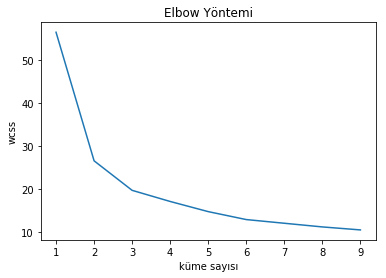

```python
wcss = []
N = 10
for i in range (1,N):
    kmeans = KMeans(n_clusters = i, init='k-means++', max_iter=300, n_init=i, random_state=1)
    kmeans.fit(dataset1)
    wcss.append(kmeans.inertia_)
plt.plot(range(1,N),wcss)
plt.title('Elbow Yöntemi')
plt.xlabel('küme sayısı')
plt.ylabel('wcss')
plt.show()
```

##### range ( , )

Ne kadar çok k değeri seçersek wcss değerleri o kadar azalır. Bu durumda 155 ülke için 155 küme merkezi seçtiğimizde datamızdaki tüm noktalarla bire bir eşleşen küme merkezlerimiz olur. Fakat küme merkezi sayısının çoğalması yapmak istediğimiz çalışmayla ters düşer. İstediğimiz optimal sayıda kümeye ayırmak.

##### random_state

random_state'i sabitlyerek, kodumuzu her çalıştırdığımızda her seferinde aynı rastgele tamsayı dizisini oluşturmasını sağlarız. random_state'i sabitlemek verilerimizin örneklenme şeklini etkiler, dağılımını etkilemez. Tutarlı sonuçlar elde etmemizi sağlayan bir parametredir.

- Aşağıda wcss2'de random_state=1, wcss3'te random_state=0 olsun. Grafik üzerinde farklılıkları inceleyelim.

##### max_iter

Bir sonraki parametre max_iter algoritmanın nihai durumuna erişmesi için en fazla kaç iterasyon yapabileceğini belirler, varsayılan 300’tür.

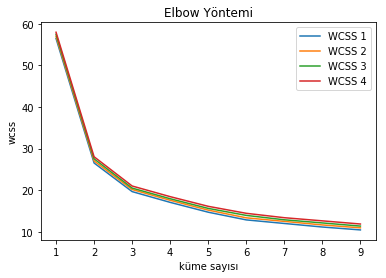

```python
wcss1=[]
wcss2=[]
wcss3=[]
wcss4=[]
for i in range (1,10):
    kmeans = KMeans(n_clusters = i, init='k-means++', n_init=i, random_state=1)
    kmeans.fit(dataset1)
    wcss1.append(kmeans.inertia_)

for i in range (1,10):
    kmeans = KMeans(n_clusters = i, init='k-means++', max_iter=150, n_init=i, random_state=1)
    kmeans.fit(dataset1)
    wcss2.append(0.5+kmeans.inertia_)

for i in range (1,10):
    kmeans = KMeans(n_clusters = i, init='k-means++', max_iter=150, n_init=i, random_state=0)
    kmeans.fit(dataset1)
    wcss3.append(1+kmeans.inertia_)

for i in range (1,10):
    kmeans = KMeans(n_clusters = i, init='k-means++', max_iter=300, n_init=i, random_state=0)
    kmeans.fit(dataset1)
    wcss4.append(1.5+kmeans.inertia_)

fig1,=plt.plot(range(1,10),wcss1, label='WCSS 1')
fig2,=plt.plot(range(1,10),wcss2, label='WCSS 2')
fig3,=plt.plot(range(1,10),wcss3, label='WCSS 3')
fig4,=plt.plot(range(1,10),wcss4, label='WCSS 4')

plt.title('Elbow Yöntemi')
plt.xlabel('küme sayısı')
plt.ylabel('wcss')
plt.legend(handles=[fig1,fig2,fig3,fig4])
plt.show()
```

- https://matplotlib.org/users/pyplot_tutorial.html

### grafik yorumu

4 adet wcss listesi oluşturduk. Burada amacımız random_state ve max_iter'deki sayısal değişikliklerin kümeleme algoritmamızı nasıl etkileceğini görmek. Bunun için parametrelerimizde küçük değişikliklerle oluşturduğumuz wcss değerlerimizi 0.5 birim aralıklarla grafiklerini çizdirip karşılaştırmayı amaçlıyoruz.

Öncelikle wcss2 ve wcss3 ile random_state parametresinde yapılan değişikliklerin etkilerini gözlemlemek istedik. wcss2'de random_state=1, wcss3'te ise 0. Grqafiğimizde WCSS 2 ve WCSS 3'e baktığımızda ve aralarında 0.5 birimlik farkı göz önüne bulundurduğumuzda bize aynı sonucu verdiklerini söylemek mümkün. Yani random_state'i kaç atarsak atayalım çalışmamızda bir değişikliğe sebep olmayacağı sonucuna varabiliriz.

Şimdi wcss1, wcss3 ve wcss4'e bakalım. Burada wcss1'de max_iter değeri yok, diğerlerinde sırasıyla 150 ve 300. Yine grafiğimizde WCSS 1, WCSS 3 ve WCSS 4 eğrilerimizi incelediğimizde bu eğrilerin bize aynı sonuçlarını verdiğini gözlemleyebiliriz. Yani max_iter değerini istediğimiz gibi seçebiliriz.

Yukarıda çizdiğimiz grafiğe geri dönecek olursak küme sayısı 3 olana kadar wcss değerleri çok hızlı bir şekilde düşüyor. Optimal küme sayısını belirleyebilmek için wcss değerinin minimum olduğu değere karşılık gelen küme sayısını almalıyız. Grafiğimizde küme sayısı 2 ve 3 değerleri için dirsek oluşuyor. wcss değeri 3 için daha az olduğundan k değerini 3 olarak belirleyelim.

#### iki k-means karşılaştırmasından hangisini seçerim?

$C_1,C_2,....C_K$ kümeleri temsil etsin. Veri setimizdeki her bir veri bu kümelerden birine dahil olsun ve bir kümede bulunan veri diğerinde bulunmasın.

İyi bir kümeleme within-cluster değişkeninin mümkün olabildiğince küçük seçilmesiyle sağlanır. $C_k$ kümesi için kümelerin birbirlerinden farkının ölçüsü $W(C_k)$ within-cluster değişkenidir. Bu durumda amacımız;

$$\underset{C_1,C_2,...,C_k}{minimize} {\sum^K_{k=1} W(C_k)}$$

Yukarıdaki formülden veri setimizi K kümeye ayıracağımızı ve K küme üzerinde within-cluster toplamının mümkün olabildiğince küçük seçileceğini anlayabiliiz.

within-cluster değişkenini tanımlamak için squared Euclidean distancetan yararlanalım.

$$W(C_k)=\dfrac{1}{|C_k|} \sum_{i,i∈C_k}\sum^P_{j=1}(x_{ij} − x_{ij} )^2 $$

$|C_k|$: k. kümedeki veri sayısı

k. küme için within-cluster değişkeni, k. kümedeki verilerin tüm ikili squared Euclidean distances toplamınin k. kümedeki toplam veri sayısına bölümüdür.

Bu iki formülü bir araya getirirsek:

$$\underset{C_1,C_2,...,C_k}{minimize} {\sum^K_{k=1} \dfrac{1}{|C_k|} \sum_{i,i∈C_k}\sum^P_{j=1}(x_{ij} − x_{ij} )^2 }$$

- https://www.ime.unicamp.br/~dias/Intoduction%20to%20Statistical%20Learning.pdf
- Zaki, Mohammed J. ve Meira Wagner Jr., Data Mining And Analysis, New York: Cambridge University Press, 2014.

Şimdi, veri setimizi yukarıda elde ettiğimiz bilgiler ve değerler doğrultusunda KMeans ile modelleyelim. fit_predict kullanarak dataset1'de yer alan her örnek için küme merkezlerini hesaplayıp küme indislerini tahmin edelim.

```python
kmeans = KMeans(n_clusters = 3, init='k-means++', max_iter=300, n_init=10, random_state=0)
y_kmeans = kmeans.fit_predict(dataset1)
```

```python
dataset2.head()
```

|  | Country | Economy..GDP.per.Capita. | Family | Health..Life.Expectancy. | Freedom | Generosity | Trust..Government.Corruption. |
| --- | --- | --- | --- | --- | --- | --- | --- |
| 0 | Norway | 1.616463 | 1.533524 | 0.796667 | 0.635423 | 0.362012 | 0.315964 |
| 1 | Denmark | 1.482383 | 1.551122 | 0.792566 | 0.626007 | 0.355280 | 0.400770 |
| 2 | Iceland | 1.480633 | 1.610574 | 0.833552 | 0.627163 | 0.475540 | 0.153527 |
| 3 | Switzerland | 1.564980 | 1.516912 | 0.858131 | 0.620071 | 0.290549 | 0.367007 |
| 4 | Finland | 1.443572 | 1.540247 | 0.809158 | 0.617951 | 0.245483 | 0.382612 |

```python
import mpld3
N=200
size=dataset.iloc[:,2]
fig, ax = plt.subplots()
plt.scatter(dataset1[y_kmeans == 0, 2], dataset1[y_kmeans == 0, 4], s = size, c = 'red', label = 'küme1')
plt.scatter(dataset1[y_kmeans == 1, 2], dataset1[y_kmeans == 1, 4], s = size, c = 'green', label = 'küme2')
plt.scatter(dataset1[y_kmeans == 2, 2], dataset1[y_kmeans == 2, 4], s = size, c = 'blue', label = 'küme3')

labels = ['point {0}'.format(i + 1) for i in range(N)]

plt.scatter(kmeans.cluster_centers_[:,2], kmeans.cluster_centers_[:,4], s=50, c='yellow', label='küme merkezleri')
tooltip = mpld3.plugins.PointLabelTooltip(scatter, labels=labels)
mpld3.plugins.connect(fig, tooltip)
mpld3.display()

plt.scatter(kmeans.cluster_centers_[:,2], kmeans.cluster_centers_[:,4], s=50, c='yellow', label='küme merkezleri')
plt.title('1. grafik')
plt.legend()
plt.show()
```

```
---------------------------------------------------------------------------
NameError                                 Traceback (most recent call last)
<ipython-input-9-98edd88d6b1d> in <module>()
     10
     11 plt.scatter(kmeans.cluster_centers_[:,2], kmeans.cluster_centers_[:,4], s=50, c='yellow', label='küme merkezleri')
---> 12 tooltip = mpld3.plugins.PointLabelTooltip(scatter, labels=labels)
     13 mpld3.plugins.connect(fig, tooltip)
     14 mpld3.display()

NameError: name 'scatter' is not defined
```

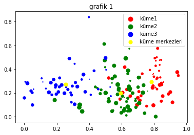

```python
size=dataset.iloc[:,1]

plt.scatter(dataset1[y_kmeans == 0, 2], dataset1[y_kmeans == 0, 4], s = size, c = 'red', label = 'küme1')
plt.scatter(dataset1[y_kmeans == 1, 2], dataset1[y_kmeans == 1, 4], s = size, c = 'green', label = 'küme2')
plt.scatter(dataset1[y_kmeans == 2, 2], dataset1[y_kmeans == 2, 4], s = size, c = 'blue', label = 'küme3')

plt.scatter(kmeans.cluster_centers_[:,2], kmeans.cluster_centers_[:,4], s=50, c='yellow', label='küme merkezleri')

plt.title('grafik 1')
plt.legend()
plt.show()
```

- https://mpld3.github.io/examples/scatter_tooltip.html
- https://jakevdp.github.io/PythonDataScienceHandbook/04.02-simple-scatter-plots.html
- https://stackoverflow.com/questions/5147112/how-to-put-individual-tags-for-a-scatter-plot
- https://plot.ly/python/line-and-scatter/

## Noktalar ile ülke adlarını eşleştirdik ama yapmasak daha iyiydi sanki??

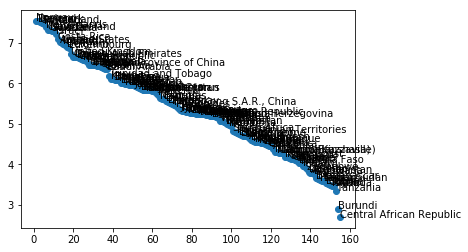

```python
y=dataset.iloc[:,1]
z=dataset.iloc[:,2]
n=dataset.iloc[:,0]

fig, ax = plt.subplots()
ax.scatter(y, z)

for i, txt in enumerate(n):
    ax.annotate(txt, (y[i],z[i]))

plt.show()
```

Grafiğimizi oluşturduk. Bu grafikte ülke mutluluklarını tüm kolonları baz alarak gruplamak mümkün değil. Sadece seçtiğimiz bir kolona bağlı sonuçların grafiğini elde edebiliyoruz.

dataset1'de yer alan kolon başlıklarımız sırasıyla Economy..GDP.per.Capita., Family, Health..Life.Expectancy.,Freedom,Generosity,Trust..Government.Corruption. Örnek olarak, yukarıda İkinci ve dördüncü kolonlara denk gelen Health..Life.Expectancy. ve Generosity verilerini baz alarak bir gruplama yapıldı. Fakat açıkca gözlenebileceği gibi farklı kümeleri temsil eden kırmızı, mavi ve yeşil renkleri birbirlerinin içine girmiş durumda. Düzgün bir gruplama olmadığı sonucuna varabiliriz.

İkinci ve dördüncü kolonlar yerine farklı kolonlar seçip grafiği tekrar tekrar çizdirebiliriz. Bizim amacımız dataset1'de yer verdiğimiz tüm kolonları kullanarak bir gruplama yapmak. Bu nedenle bu şekilde 2 kolon baz alarak çizdirdiğimiz grafik işimize yaramayacaktır.

Şimdi dataset1'de yer alan tüm kolonları yukarıdaki gibi ikili gruplayarak grafiklerini çizdirelim.

- https://www.youtube.com/watch?v=MTrzkAinc98&list=PLv7Aer2xCx3d0aSlDJNp-lISDvmo_Eb5G

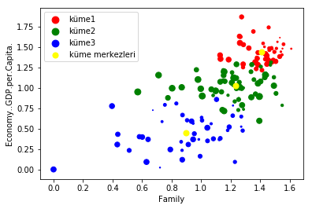

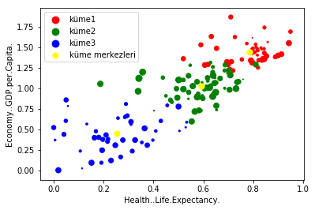

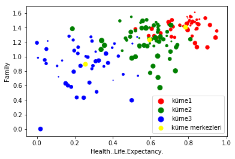

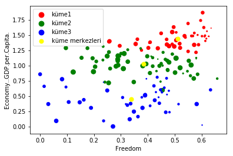

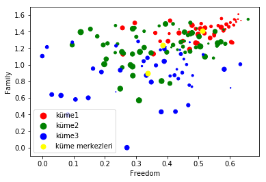

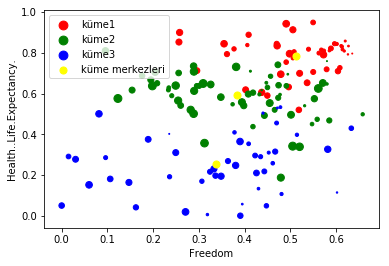

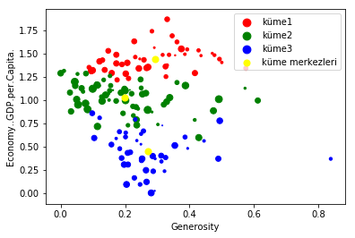

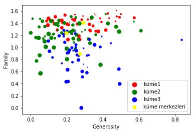

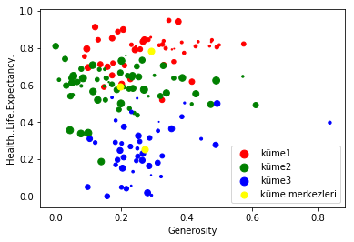

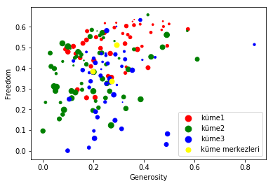

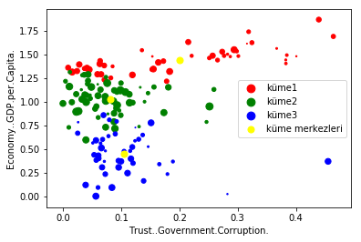

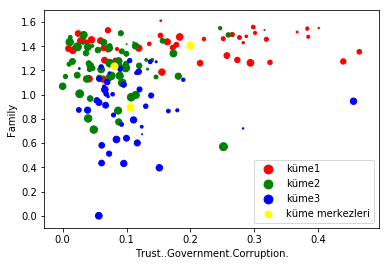

[3 more figures not shown]

```python
for i in range(0,6):
    for j in range(0,6):
        if (i==j): break

        else:

            plt.scatter(dataset1[y_kmeans == 0, i], dataset1[y_kmeans == 0, j], s = size, c = 'red', label = 'küme1')
            plt.scatter(dataset1[y_kmeans == 1, i], dataset1[y_kmeans == 1, j], s = size, c = 'green', label = 'küme2')
            plt.scatter(dataset1[y_kmeans == 2, i], dataset1[y_kmeans == 2, j], s = size, c = 'blue', label = 'küme3')

            plt.scatter(kmeans.cluster_centers_[:,i], kmeans.cluster_centers_[:,j], s=50, c='yellow', label='küme merkezleri')
            plt.xlabel(dataset3.columns[i])
            plt.ylabel(dataset3.columns[j])
            plt.legend()
            plt.show()
```

- https://www.digitalocean.com/community/tutorials/how-to-construct-for-loops-in-python-3
- https://www.quora.com/What-are-the-best-examples-of-a-Nested-Loops-for-Python
- https://www.tutorialspoint.com/python/python_nested_loops.htm
- https://stackoverflow.com/questions/22007492/prime-number-python-nested-loops
- https://stackoverflow.com/questions/41065354/break-for-loop-in-an-if-statement

İkili kolonlar bazında grafik yorumu yapmak bizi doğru yönlendirmeyeceğinden yani tüm kolonları baz alarak bir sonuca varmak istediğimizden veri setimizdeki 155 ülkeyi farklı bir yöntemle 3 kümeye ayırmayı deneyelim.

```python
kmeans = KMeans(n_clusters=3, random_state=0).fit(dataset1)
labels = kmeans.labels_
labels
```

```
array([0, 0, 0, 0, 0, 0, 0, 0, 0, 0, 0, 1, 0, 0, 0, 0, 0, 0, 0, 0, 0, 1,
       0, 1, 1, 0, 0, 0, 1, 0, 0, 1, 0, 0, 0, 1, 0, 0, 0, 0, 0, 0, 1, 1,
       1, 0, 1, 0, 1, 1, 0, 1, 1, 1, 0, 1, 1, 1, 1, 0, 0, 0, 1, 1, 0, 0,
       1, 1, 1, 1, 0, 1, 1, 1, 1, 1, 1, 1, 1, 2, 1, 1, 1, 1, 1, 1, 1, 1,
       0, 1, 1, 1, 2, 1, 2, 2, 1, 1, 2, 1, 1, 1, 1, 1, 1, 2, 2, 1, 1, 2,
       1, 2, 2, 2, 2, 2, 1, 1, 2, 1, 1, 2, 2, 2, 1, 2, 2, 2, 2, 2, 2, 1,
       2, 2, 2, 2, 2, 2, 2, 2, 2, 1, 2, 2, 2, 2, 2, 2, 2, 2, 2, 2, 2, 2,
       2])
```

Önce grafik kullanarak oluşturduğumuz üç kümeyi gözlemlemek istedik fakat istediğimiz gibi tüm kolonları kullanamadık. Şimdi ise tüm kolonları dahil etmemize rağmen yukarıdaki algoritma ile kümeleme sonucumuz ikna edici olmadı.

Yukarıdaki 0, 1, 2 değerlerini bir de grafik üzerinde görelim.

- https://plot.ly/python/candlestick-charts/

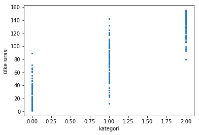

```python
happscore=dataset.iloc[:,1].values
plt.scatter(labels, happscore, s = 5)
plt.figure(1, figsize=(5, 3))
plt.xlabel('kategori')
plt.ylabel('ülke sırası')
plt.show()
```

Yukarıda elde ettiğimiz 0,1,2 kümeleri ile veri setimizde yer alan ülkelerin mutluluk sılarının grafiğini çizdirdik. 0 ve 2 kümeleri 1'e nispeten daha doğru sonuçlar vermekte. Bazı sapmalar olmasına rağmen çoğunlukla 0-70 aralığındaki ülkelerin 0 kümesinde, 100-155'in 2 kümesinde yer aldığını görüyoruz. Fakat 1 kümesinde 10-140 sıralamasındaki ülkeler yer alıyor. Bu denli geniş bir aralık bizi yanıltacaktır. Kümeleme algoritmamız 0 ve 2 gruplamasında doğru 1 için yanlış çalıştığını söyleyebiliriz.

Şimdiye kadar yaptıklarımız bizi net bir sonuca ulaştırmadığından farklı bir yöntem deneyeceğiz.

## linear discriminant analysis - doğrusal diskriminant analizi

Bu analiz ile mutluluk seviyelerine göre 3 kümeye ayırdığımız 155 ülkeye farklı bir açıdan bakmayı amaçlıyoruz. Öyle bir açıdan gruplanmış ülkelere bakacağız ki izdüşümleri gerçekten dataset1'de yer alan kolonlardaki değerlerin ülkelerin mutluluk gruplandırmasında ilişkisi var mı yok mu bize söylüyor olacak. Yani baktığımız açıdan, kolonlar ile mutluluk arasında bir ilişki varsa düzgün gruplandırılmış bir grafik görüyor olacağız. Düzgün gruplandırılmış ile anlatmak istediğimiz mutluluk seviyelerine göre ayırdığımız kümelerimizi temsil eden kırmızı, mavi, yeşil renklerin birbirlerinin içine geçmeden homojen bir şekilde gruplanmış olması.

Analizimizi gerçekleştirmek için LinearDiscriminantAnalysis fonksiyonunu kullanacağız. Öncelikle bu fonksiyonun nasıl çalıştığına, teorik kısmına kısaca değinelim.

İki veya daha fazla nesne veya olayı sınıflandıran veya ayıran özelliklerin doğrusal bir kombinasyonunu bulmak için istatistiksel bir yöntemdir.

Elde edilen kombinasyon, lineer bir sınıflandırıcı olarak veya daha sonraki sınıflandırma öncesi boyut küçültme için kullanılabilir.

LDA, diğer özelliklerin veya ölçümlerin doğrusal bir kombinasyonu olarak bir bağımlı değişkeni ifade etmeye çalışan varyans analizi (ANOVA) ve regresyon analizi ile yakından ilişkilidir.

##### LDA yaklaşımı

Doğrusal diskriminant analizi yapmak için 5 genel adımı listeleyelim;

1.Veri kümesinden farklı sınıflar için d boyutlu ortalama(mean) vektörleri hesaplanır.

2.Dağılım(scatter) matrislerini (in-between-class ve within-class scatter) hesaplanır.

3.Dağılım matrisleri için özvektörleri (*$ e_1 , e_2, ..., e_d $*) ve karşılık gelen özdeğerleri (*$\lambda_1 , \lambda_2, ... , \lambda_d$*) hesaplanır.

4.Özdeğerleri azaltarak özvektörleri sıralanır ve **d × k** boyutlu matris **W** (her sütunun bir özvektörü temsil ettiği) oluşturmak için en büyük özdeğerleri olan **k** özvektörlerini seçilir.

5.Örnekleri yeni alt uzay üzerine dönüştürmek için bu **d × k** özvektör matrisini kullanılır. Bu, matris çarpımı ile özetlenebilir: **Y = X × W** (burada **X**, n örneklerini temsil eden bir n × d boyutlu matrisidir ve y yeni uzayda dönüştürülmüş n × k boyutlu örneklerdir.)

LDA, iyi sınıf (hedefler) arasında en iyi şekilde ayıran değişkenleri lineer bir kombinasyonunu aramaya dayanır. Fisher aşağıdaki score fonksiyonunu tanımlar.

$Z=\beta_1 x_1 + \beta_2 x_2 + .... + \beta_d x_d $

$S(\beta)= \frac{\beta^T \mu_1 - \beta^T \mu_2 }{\beta^T C \beta} \hspace{1cm}$ *Score fonksiyonu*

$S(\beta)= \frac{\overline {Z_1} - \overline {Z_2 }}{Z'nin gruptaki varyansı}$

Score fonksiyonuna göre, problem score’u maksimize eden lineer katsayıları tahmin etmedir. Formülasyonu:

$\beta= C^{-1} (\mu_1 - \mu_2) \hspace{1cm}$ *Model katsayıları*

$C= \frac{1}{n_1 + n_2}(n_1C_1+n_2C_2) \hspace{1cm}$ *Toplanmış kovaryans matrisi*

$ \beta $: lineer model katsayıları $\hspace{1cm}$ $ C_1,C_2 $ : kovaryans matrisi $\hspace{1cm}$ $ \mu_1 , \mu_2 $ : ortalama vektörler

En iyi diskriminantı belirleme yolu iki grup arasında Mahalanobis mesafesini hesaplamaktır. Mahalanobis mesafesinin üçten küçük olması yanlış sınıflandırma olasılığını oldukça küçük olduğunu anlamına gelir.

$ \Delta^2 = \beta^T (\mu_1 - \mu_2) $

$ \Delta$ : iki grup arası Mahalanobis farkı

Son olarak, eğer aşağıdaki şart sağlanırsa yeni gelen bir özellik sınıflandırılır.

$\beta^T =(x- ( \frac{ \mu_1 + \mu_2 }{2} )) > log \frac{ p(c_1) }{p(c_2)} $

$ \beta^T $: katsayı vektörü $\hspace{1cm}$ x: veri vektörü

$ \frac{ \mu_1 + \mu_2 }{2} $ : ortalama vektörü $\hspace{1cm}$ $ log \frac{ p(c_1) }{p(c_2)} $ : sınıf olasılıkları

- http://scikit-learn.org/stable/modules/generated/sklearn.discriminant_analysis.LinearDiscriminantAnalysis.html
- http://sebastianraschka.com/Articles/2014_python_lda.html
- http://www.saedsayad.com/lda.htm

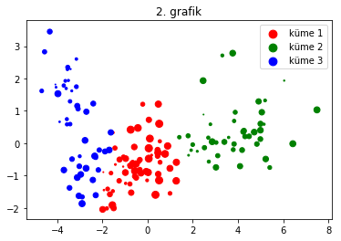

```python
from sklearn.discriminant_analysis import LinearDiscriminantAnalysis
y=labels
X_norm=dataset1
lda = LinearDiscriminantAnalysis(n_components=2) #2-dimensional LDA
lda_transformed = pd.DataFrame(lda.fit_transform(X_norm, y))

# Plot all three series
plt.scatter(lda_transformed[y==1][0], lda_transformed[y==1][1], label='küme 1', c='red', s=size)
plt.scatter(lda_transformed[y==2][0], lda_transformed[y==2][1], label='küme 2', c='green', s=size )
plt.scatter(lda_transformed[y==0][0], lda_transformed[y==0][1], label='küme 3', c='blue', s=size)

# Display legend and show plot
plt.legend()
plt.title('2. grafik')
plt.show()
```

Grafiğimizde mavi, kırmızı ve yeşil noktalar açıkça görüldüğü üzere birbirleri içine geçmeden, her renk kendi grubunu oluşturacak şekilde yer almaktadır. Doğrusal diskriminant analizi ile diğer yöntemler ile kesin sonuca varamadığımız kolonlar ve ülkelerin mutluluğu arasındaki ilişkinin varlığını göstermiş olduk.

Daha önceden oluşturduğumuz 1. grafik ile yukarıdaki 2. grafiği karşılaştıralım. 1. grafikte belirlediğimiz iki kolona göre kümeleme yapıyorduk, 2. grafikte ise tüm kolonlara göre kümeleme yapıyoruz. 1. grafikte homojen bir kümeleme sonucuna ulaşamamıştık, 2. grafikte ise kümeleme işlemi homojen bir şekilde gerçekleşti. 1. grafikte iki boyut üzerinde çalışıp izdüşümünü düzleme yansıttık, 2. grafikte tüm kolonları baz aldığımızdan daha çok boyutta çalışıp düzleme yansıttık. 2. grafikte 1. grafikte yer almayan farklı bir açıdan izdüşüm alma yöntemi sayesinde verilerimizi düzgün kümeleyecebileceğimizi gördük.

### spearmanr korelasyonu - iki değişken arasındaki ilişki

Korelasyon analizi, iki değişken arasındaki ilişkiyi veya bir değişkenin iki veya daha çok değişken ile olan ilişkisini test etmek, varsa bu ilişkinin derecesini ölçmek için kullanılan istatistiksel bir yöntemdir.

Korelasyon analizinde amaç; bağımsız değişken (X) değiştiğinde, bağımlı değişkenin (Y) ne yönde değişeceğini görmektir.

Pozitif korelasyon: X değişkeninin değerinin artması(azalması) durumunda Y değişkeninin değerlerinin de artma(azalma) eğiliminde olduğu anlaşılır.

Negatif korelasyon: X değişkeninin değerinin artması (azalma) durumunda Y değişkeninin değerlerinin de azalma (artma) eğiliminde olduğu anlaşılır.

- https://en.wikipedia.org/wiki/Spearman%27s_rank_correlation_coefficient
- http://benalexkeen.com/correlation-in-python/
- https://towardsdatascience.com/building-a-logistic-regression-in-python-step-by-step-becd4d56c9c8

#### pearson korelasyonu

İki sayısal ölçüm arasında doğrusal bir ilişki olup olmadığını, varsa bu ilişkinin yönünü ve şiddetininin ne olduğunu belirlemek için kullanılan bir istatistiksel yöntemdir. Verilerin normal dağılıma sahip olması durumunda Pearson korelasyon katsayısı, verilerin normal dağılmadığı durumda ise Spearman Rank korelasyon katsayısı tercih edilir. Bir korelasyon katsayısının yorumlanabilmesi için p değerinin 0.05 den daha küçük olması gerekir.

Korelasyon katsayısı negatif ise iki değişken arasında ters ilişki vardır, yani "değişkenlerden biri artarken diğeri azalmaktadır" denir. Korelasyon katsayısı pozitif ise "değişkenlerden biri artarken diğeride artmaktadır" yorumu yapılır.

- 0,00 – 0,25 : Çok Zayıf
- 0,26 – 0,49 : Zayıf
- 0,50 – 0,69 : Orta
- 0,70 – 0,89 : Yüksek
- 0,90 – 1,00 : Çok Yüksek

#### korelasyon matrisi

- https://jakevdp.github.io/PythonDataScienceHandbook/04.07-customizing-colorbars.html

```python
from pandas import Series, DataFrame
import scipy
from scipy.stats import spearmanr
from pylab import rcParams
import seaborn as sb
import sklearn
from sklearn.preprocessing import scale
from sklearn.linear_model import LogisticRegression
from sklearn.model_selection import train_test_split
from sklearn import metrics
from sklearn import preprocessing
```

Sırada kolonlarımız ile Happiness.Score arasındaki ilişkiyi göstermek var. Bunun için spearmanr_coefficient fonksiyonunu kullanacağız. veri setimizdeki kullanacağımız kolonların tek tek kolonların Happiness.Score ile olan ilişkisini hesaplatacağız.

```python
spearmanr_coefficient, p_value=spearmanr(dataset['Happiness.Score'], dataset['Economy..GDP.per.Capita.'])
print (("Spearmanr rank coefficient: Happiness Score & Economy = %0.3f") %(spearmanr_coefficient))

spearmanr_coefficient, p_value=spearmanr(dataset['Happiness.Score'], dataset['Family'])
print (("Spearmanr rank coefficient: Happiness Score & Family = %0.3f") %(spearmanr_coefficient))

spearmanr_coefficient, p_value=spearmanr(dataset['Happiness.Score'], dataset['Health..Life.Expectancy.'])
print (("Spearmanr rank coefficient: Happiness Score & Health = %0.3f") %(spearmanr_coefficient))

spearmanr_coefficient, p_value=spearmanr(dataset['Happiness.Score'], dataset['Freedom'])
print (("Spearmanr rank coefficient: Happiness Score & Freedom = %0.3f") %(spearmanr_coefficient))

spearmanr_coefficient, p_value=spearmanr(dataset['Happiness.Score'], dataset['Generosity'])
print (("Spearmanr rank coefficient: Happiness Score & Generosity = %0.3f") %(spearmanr_coefficient))

spearmanr_coefficient, p_value=spearmanr(dataset['Happiness.Score'], dataset['Trust..Government.Corruption.'])
print (("Spearmanr rank coefficient: Happiness Score & Trust = %0.3f") %(spearmanr_coefficient))
```

```
Spearmanr rank coefficient: Happiness Score & Economy = 0.825
Spearmanr rank coefficient: Happiness Score & Family = 0.774
Spearmanr rank coefficient: Happiness Score & Health = 0.788
Spearmanr rank coefficient: Happiness Score & Freedom = 0.556
Spearmanr rank coefficient: Happiness Score & Generosity = 0.136
Spearmanr rank coefficient: Happiness Score & Trust = 0.301
```

```python
pd.scatter_matrix(son, figsize=(10, 10))
plt.show()
```

```
---------------------------------------------------------------------------
NameError                                 Traceback (most recent call last)
<ipython-input-31-8f963566ec55> in <module>()
----> 1 pd.scatter_matrix(son, figsize=(10, 10))
      2 plt.show()

NameError: name 'son' is not defined
```

```python
dataset3.head()
```

|  | Economy..GDP.per.Capita. | Family | Health..Life.Expectancy. | Freedom | Generosity | Trust..Government.Corruption. |
| --- | --- | --- | --- | --- | --- | --- |
| 0 | 1.616463 | 1.533524 | 0.796667 | 0.635423 | 0.362012 | 0.315964 |
| 1 | 1.482383 | 1.551122 | 0.792566 | 0.626007 | 0.355280 | 0.400770 |
| 2 | 1.480633 | 1.610574 | 0.833552 | 0.627163 | 0.475540 | 0.153527 |
| 3 | 1.564980 | 1.516912 | 0.858131 | 0.620071 | 0.290549 | 0.367007 |
| 4 | 1.443572 | 1.540247 | 0.809158 | 0.617951 | 0.245483 | 0.382612 |

Ve korelasyon matrisini de çizdirelim aynı kolonlar için. Amacımız kolonların birbirleriyle olan ilişkilerini gözlemlemek, mutluluk skorunu hangi alanların ne kadar etkilediğini incelemek ve bunlar doğrultusunda kolon sayısında azaltmaya gitmek.

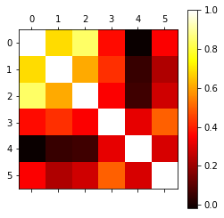

```python
from pandas import DataFrame
plt.matshow(DataFrame.corr(dataset3), cmap='hot')
plt.colorbar()
plt.show()
```

## Multinomial Logistic Regression

- http://dataaspirant.com/2017/05/15/implement-multinomial-logistic-regression-python/

```python
from sklearn import preprocessing
plt.rc("font", size=14)
from sklearn.linear_model import LogisticRegression
from sklearn.cross_validation import train_test_split
import seaborn as sns
sns.set(style="white")
sns.set(style="whitegrid", color_codes=True)
import numpy as np
```

```python
print(dataset_1.shape)
print(list(dataset_1.columns))
```

```
---------------------------------------------------------------------------
NameError                                 Traceback (most recent call last)
<ipython-input-43-cb8c76c1bb39> in <module>()
----> 1 print(dataset_1.shape)
      2 print(list(dataset_1.columns))

NameError: name 'dataset_1' is not defined
```

```python
dataset['Country'].unique
```

```
<bound method Series.unique of 0                        Norway
1                       Denmark
2                       Iceland
3                   Switzerland
4                       Finland
5                   Netherlands
6                        Canada
7                   New Zealand
8                        Sweden
9                     Australia
10                       Israel
11                   Costa Rica
12                      Austria
13                United States
14                      Ireland
```

[output cut: 47 more lines]

```python
dataset['Happiness.Score'].value_counts()
```

[output not shown]

[figure not shown]

```python
sns.countplot(x='Happiness.Score', data=dataset, palette='hls')
plt.show()
plt.savefig('count_plot')
```

```python
lr = LogisticRegression()
```

```python
dataset_1_train=np.array
```

```python
LogisticRegression(multi_class='multinomial',solver ='lbfgs').fit(x_train,x_train)
```

```
---------------------------------------------------------------------------
NameError                                 Traceback (most recent call last)
<ipython-input-49-83af8613b7ad> in <module>()
----> 1 LogisticRegression(multi_class='multinomial',solver ='lbfgs').fit(x_train,x_train)

NameError: name 'x_train' is not defined
```

```python
y =x.target[:-1]
```

```
---------------------------------------------------------------------------
NameError                                 Traceback (most recent call last)
<ipython-input-50-055554822318> in <module>()
----> 1 y =x.target[:-1]

NameError: name 'x' is not defined
```

```python
from pandas import Series, DataFrame

import scipy
from scipy.stats import spearmanr

from pylab import rcParams
import seaborn as sb

import sklearn
from sklearn.preprocessing import scale
from sklearn.linear_model import LogisticRegression
from sklearn.model_selection import train_test_split
from sklearn import metrics
from sklearn import preprocessing
```

```python
%matplotlib inline
rcParams['figure.figsize']=5, 4
```

```python
dataset_1.columns
```

```
---------------------------------------------------------------------------
NameError                                 Traceback (most recent call last)
<ipython-input-53-cde7c53620ae> in <module>()
----> 1 dataset_1.columns

NameError: name 'dataset_1' is not defined
```

```python
x_names = ['Economy..GDP.per.Capita.','Health..Life.Expectancy.']
```

```python
sb.regplot(x='Economy..GDP.per.Capita.',y='Health..Life.Expectancy.', data=dataset_1, scatter=True)
```

```
---------------------------------------------------------------------------
NameError                                 Traceback (most recent call last)
<ipython-input-55-d259e71f8b18> in <module>()
----> 1 sb.regplot(x='Economy..GDP.per.Capita.',y='Health..Life.Expectancy.', data=dataset_1, scatter=True)

NameError: name 'dataset_1' is not defined
```

```python
Economy = dataset1['Economy..GDP.per.Capita.']
Health = dataset1['Health..Life.Expectancy.']
spearmanr_coefficient, p_value=spearmanr(Economy, Health)

print (("Spearmanr rank coefficient = %0.3f") %(spearmanr_coefficient))
```

```
---------------------------------------------------------------------------
IndexError                                Traceback (most recent call last)
<ipython-input-56-830ad6f2000c> in <module>()
----> 1 Economy = dataset1['Economy..GDP.per.Capita.']
      2 Health = dataset1['Health..Life.Expectancy.']
      3 spearmanr_coefficient, p_value=spearmanr(Economy, Health)
      4
      5 print (("Spearmanr rank coefficient = %0.3f") %(spearmanr_coefficient))

IndexError: only integers, slices (`:`), ellipsis (`...`), numpy.newaxis (`None`) and integer or boolean arrays are valid indices
```

```python
y.isnull().sum()
```

```
---------------------------------------------------------------------------
AttributeError                            Traceback (most recent call last)
<ipython-input-57-68456ab7022e> in <module>()
----> 1 y.isnull().sum()

AttributeError: 'numpy.ndarray' object has no attribute 'isnull'
```

```python
sb.countplot(x='Freedom', data = dataset_1, palette ='hls')
```

```
---------------------------------------------------------------------------
NameError                                 Traceback (most recent call last)
<ipython-input-58-c3d545d6bb29> in <module>()
----> 1 sb.countplot(x='Freedom', data = dataset_1, palette ='hls')

NameError: name 'dataset_1' is not defined
```

```python
dataset_1.info()
```

```
---------------------------------------------------------------------------
NameError                                 Traceback (most recent call last)
<ipython-input-59-09059af8d068> in <module>()
----> 1 dataset_1.info()

NameError: name 'dataset_1' is not defined
```

```python
X = scale(x)
```

```
---------------------------------------------------------------------------
NameError                                 Traceback (most recent call last)
<ipython-input-60-4d6871b81ff5> in <module>()
----> 1 X = scale(x)

NameError: name 'x' is not defined
```

```python
z=dataset.ix[:,7].values
```

```python
LogReg=LogisticRegression()

LogReg.fit(X,z)
```

```
---------------------------------------------------------------------------
NameError                                 Traceback (most recent call last)
<ipython-input-62-e825ef322cf7> in <module>()
      1 LogReg=LogisticRegression()
      2
----> 3 LogReg.fit(X,z)

NameError: name 'X' is not defined
```

```python
print LogReg.score(X,y)
```

```
  File "<ipython-input-63-4a8ed40126f6>", line 3
    print LogReg.score(X,y)
               ^
SyntaxError: invalid syntax
```

# son deneme

```python
import pandas as pd
import numpy as np
from sklearn import linear_model
from sklearn import metrics
from sklearn.cross_validation import train_test_split

import plotly.graph_objs as go
import plotly.plotly as py
from plotly.graph_objs import *
py.sign_in('MeltemAkdogan', 'uYx08pzRyIN6yopzDmL1')
```

```python
dataset = pd.read_csv(r"C:\Python37\2017.csv")
dataset.head()

DATASET_PATH = r"C:\Python37\2017.csv"
dataset.head()
```

|  | Country | Happiness.Rank | Happiness.Score | Whisker.high | Whisker.low | Economy..GDP.per.Capita. | Family | Health..Life.Expectancy. | Freedom | Generosity | Trust..Government.Corruption. | Dystopia.Residual |
| --- | --- | --- | --- | --- | --- | --- | --- | --- | --- | --- | --- | --- |
| 0 | Norway | 1 | 7.537 | 7.594445 | 7.479556 | 1.616463 | 1.533524 | 0.796667 | 0.635423 | 0.362012 | 0.315964 | 2.277027 |
| 1 | Denmark | 2 | 7.522 | 7.581728 | 7.462272 | 1.482383 | 1.551122 | 0.792566 | 0.626007 | 0.355280 | 0.400770 | 2.313707 |
| 2 | Iceland | 3 | 7.504 | 7.622030 | 7.385970 | 1.480633 | 1.610574 | 0.833552 | 0.627163 | 0.475540 | 0.153527 | 2.322715 |
| 3 | Switzerland | 4 | 7.494 | 7.561772 | 7.426227 | 1.564980 | 1.516912 | 0.858131 | 0.620071 | 0.290549 | 0.367007 | 2.276716 |
| 4 | Finland | 5 | 7.469 | 7.527542 | 7.410458 | 1.443572 | 1.540247 | 0.809158 | 0.617951 | 0.245483 | 0.382612 | 2.430182 |

```python
def scatter_with_color_dimension_graph(feature, target, layout_labels):
    """
    Scatter with color dimension graph to visualize the density of the
    Given feature with target
    :param feature:
    :param target:
    :param layout_labels:
    :return:
    """
    trace1 = go.Scatter(
        y=feature,
        mode='markers',
        marker=dict(
            size='16',
            color=target,
            colorscale='Viridis',
            showscale=True
        )
    )
    layout = go.Layout(
        title=layout_labels[2],
        xaxis=dict(title=layout_labels[0]), yaxis=dict(title=layout_labels[1]))
    data = [trace1]
    fig = Figure(data=data, layout=layout)
    # plot_url = py.plot(fig)
    py.image.save_as(fig, filename=layout_labels[1] + '_Density.png')
```

```python
def main():

    print ("dataset_RI :: "), list(dataset["RI"][:10])
    print ("dataset_target ::") , np.array([1, 1, 1, 2, 2, 3, 4, 5, 6, 7])

if __name__ == "__main__":
    main()
```

```
dataset_RI ::
```

[output not shown]

[output cut: 21 more lines]

[output not shown]

http://dataaspirant.com/2017/05/15/implement-multinomial-logistic-regression-python/

```python
print(__doc__)
# Authors: Tom Dupre la Tour <tom.dupre-la-tour@m4x.org>
# License: BSD 3 clause

import numpy as np
import matplotlib.pyplot as plt
from sklearn.datasets import make_blobs
from sklearn.linear_model import LogisticRegression

# make 3-class dataset for classification
centers = [[-5, 0], [0, 1.5], [5, -1]]
X, y = make_blobs(n_samples=1000, centers=centers, random_state=40)
transformation = [[0.4, 0.2], [-0.4, 1.2]]
X = np.dot(X, transformation)

for multi_class in ('multinomial', 'ovr'):
    clf = LogisticRegression(solver='sag', max_iter=100, random_state=42,
                             multi_class=multi_class).fit(X, y)

    # print the training scores
    print("training score : %.3f (%s)" % (clf.score(X, y), multi_class))

    # create a mesh to plot in
    h = .02  # step size in the mesh
    x_min, x_max = X[:, 0].min() - 1, X[:, 0].max() + 1
    y_min, y_max = X[:, 1].min() - 1, X[:, 1].max() + 1
    xx, yy = np.meshgrid(np.arange(x_min, x_max, h),
                         np.arange(y_min, y_max, h))

    # Plot the decision boundary. For that, we will assign a color to each
    # point in the mesh [x_min, x_max]x[y_min, y_max].
    Z = clf.predict(np.c_[xx.ravel(), yy.ravel()])
    # Put the result into a color plot
    Z = Z.reshape(xx.shape)
    plt.figure()
    plt.contourf(xx, yy, Z, cmap=plt.cm.Paired)
    plt.title("Decision surface of LogisticRegression (%s)" % multi_class)
    plt.axis('tight')

    # Plot also the training points
    colors = "bry"
    for i, color in zip(clf.classes_, colors):
        idx = np.where(y == i)
        plt.scatter(X[idx, 0], X[idx, 1], c=color, cmap=plt.cm.Paired,
                    edgecolor='black', s=20)

    # Plot the three one-against-all classifiers
    xmin, xmax = plt.xlim()
    ymin, ymax = plt.ylim()
    coef = clf.coef_
    intercept = clf.intercept_

    def plot_hyperplane(c, color):
        def line(x0):
            return (-(x0 * coef[c, 0]) - intercept[c]) / coef[c, 1]
        plt.plot([xmin, xmax], [line(xmin), line(xmax)],
                 ls="--", color=color)

    for i, color in zip(clf.classes_, colors):
        plot_hyperplane(i, color)

plt.show()
```